# TP 2 - ANALYSE BIVARIEE

## 1) Analyse bivariée entre deux variables quantitatives

Import des librairies Python :

```python
import numpy as np
import pandas as pd
import matplotlib.pyplot as plt
import geopandas as gpd
```

Ouverture du jeu de données filosofi :

```python
filosofi = gpd.read_file("carreaux_1km_met.shp")
```

```python
filosofi.head()#Inspecter les 5 premières lignes du jeu de données
```

|  | idcar_1km | i_est_1km | lcog_geo | ind | men | men_pauv | men_1ind | men_5ind | men_prop | men_fmp | ... | ind_6_10 | ind_11_17 | ind_18_24 | ind_25_39 | ind_40_54 | ind_55_64 | ind_65_79 | ind_80p | ind_inc | geometry |
| --- | --- | --- | --- | --- | --- | --- | --- | --- | --- | --- | --- | --- | --- | --- | --- | --- | --- | --- | --- | --- | --- |
| 0 | CRS3035RES1000mN2029000E4252000 | 1 | 2A041 | 3.0 | 1.4 | 0.3 | 0.5 | 0.1 | 0.8 | 0.1 | ... | 0.2 | 0.2 | 0.3 | 0.2 | 0.6 | 0.2 | 1.0 | 0.3 | 0.0 | POLYGON ((1218038.251 6048790.697, 1217949.529... |
| 1 | CRS3035RES1000mN2029000E4254000 | 1 | 2A041 | 2.0 | 0.9 | 0.2 | 0.3 | 0.0 | 0.5 | 0.0 | ... | 0.1 | 0.1 | 0.2 | 0.1 | 0.4 | 0.1 | 0.7 | 0.3 | 0.0 | POLYGON ((1220028.075 6048968.632, 1219939.34 ... |
| 2 | CRS3035RES1000mN2030000E4252000 | 1 | 2A041 | 6.0 | 2.5 | 0.3 | 0.3 | 0.1 | 1.6 | 0.5 | ... | 0.1 | 0.5 | 0.3 | 0.7 | 1.5 | 1.4 | 1.1 | 0.3 | 0.0 | POLYGON ((1217949.529 6049793.871, 1217860.808... |
| 3 | CRS3035RES1000mN2030000E4253000 | 1 | 2A041 | 16.5 | 6.9 | 0.7 | 1.0 | 0.3 | 4.3 | 1.3 | ... | 0.3 | 1.3 | 1.0 | 2.0 | 4.0 | 3.7 | 3.0 | 0.7 | 0.0 | POLYGON ((1218944.435 6049882.842, 1218855.707... |
| 4 | CRS3035RES1000mN2030000E4254000 | 1 | 2A041 | 5.0 | 2.4 | 0.5 | 0.9 | 0.1 | 1.4 | 0.1 | ... | 0.2 | 0.4 | 0.5 | 0.4 | 1.0 | 0.4 | 1.6 | 0.5 | 0.0 | POLYGON ((1219939.34 6049971.805, 1219850.606 ... |

5 rows × 32 columns

On va étudier le lien entre les deux variables choisies suivantes :

- ind_80p (Population de plus de 80 ans)
- log_av45 (Nombre de ménages dans un logement d'avant 1945)

```python
!pip install mapclassify
```

```
Downloading mapclassify-2.10.0-py3-none-any.whl (882 kB)
   ━━━━━━━━━━━━━━━━━━━━━━━━━━━━━━━━━━━━━━━━ 882.2/882.2 kB 13.8 MB/s eta 0:00:00
```

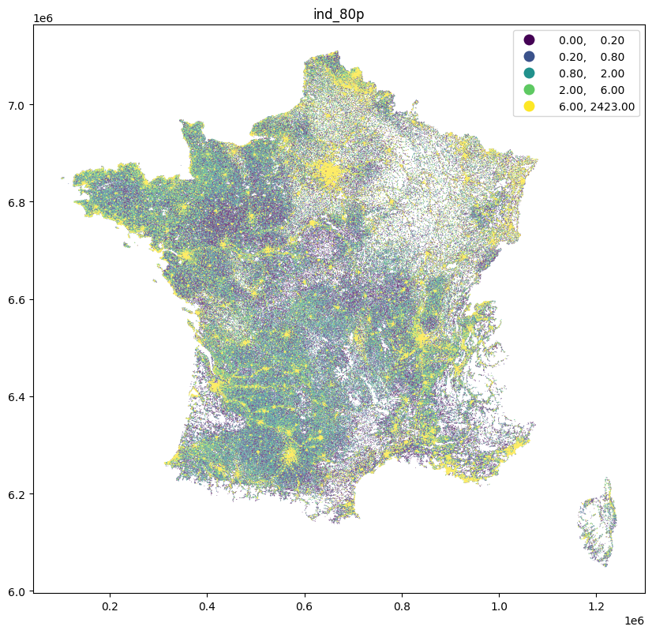

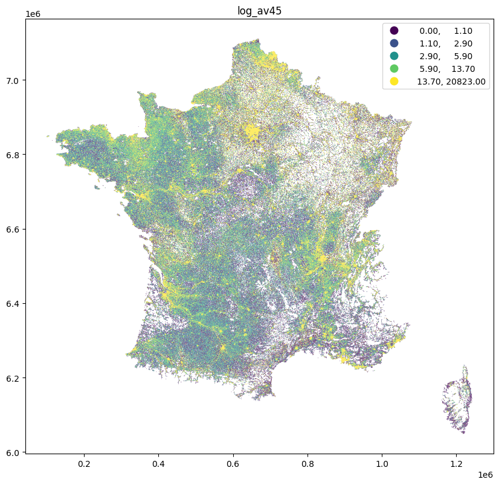

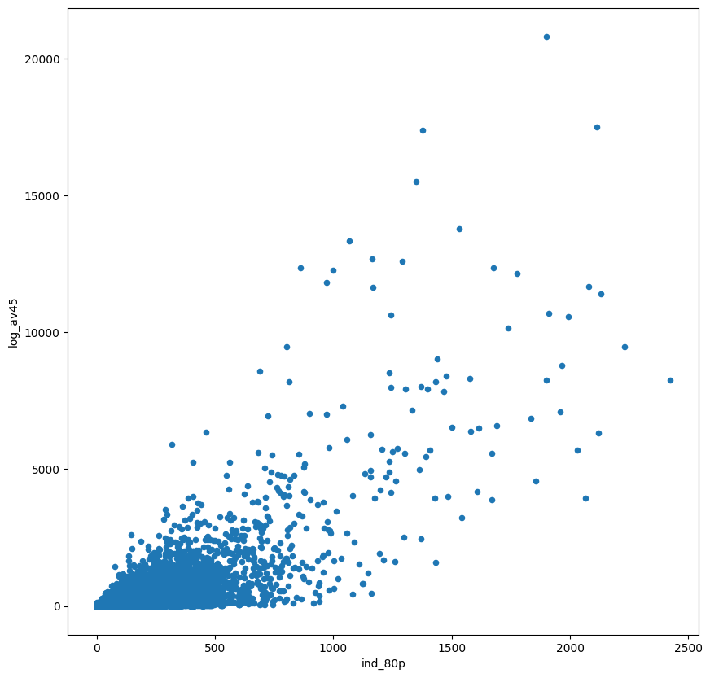

```python
import mapclassify
var_1 = "ind_80p"
var_2 = "log_av45"
filosofi.plot(figsize=(10,10), column=var_1, legend=True, scheme="quantiles", k=5).set_title(var_1)
filosofi.plot(figsize=(10,10), column=var_2, legend=True, scheme="quantiles", k=5).set_title(var_2)
filosofi.plot(figsize=(10,10), kind="scatter", x=var_1, y=var_2)
```

On voit que les distributions des deux variables sont très asymétriques vers la droite. On va donc refaire le scatter plot avec une échelle logarithmique. On peut aussi se questionner sur la présence de valeurs non entières sur les cartes. Elles viennent en fait des valeurs "imputées".

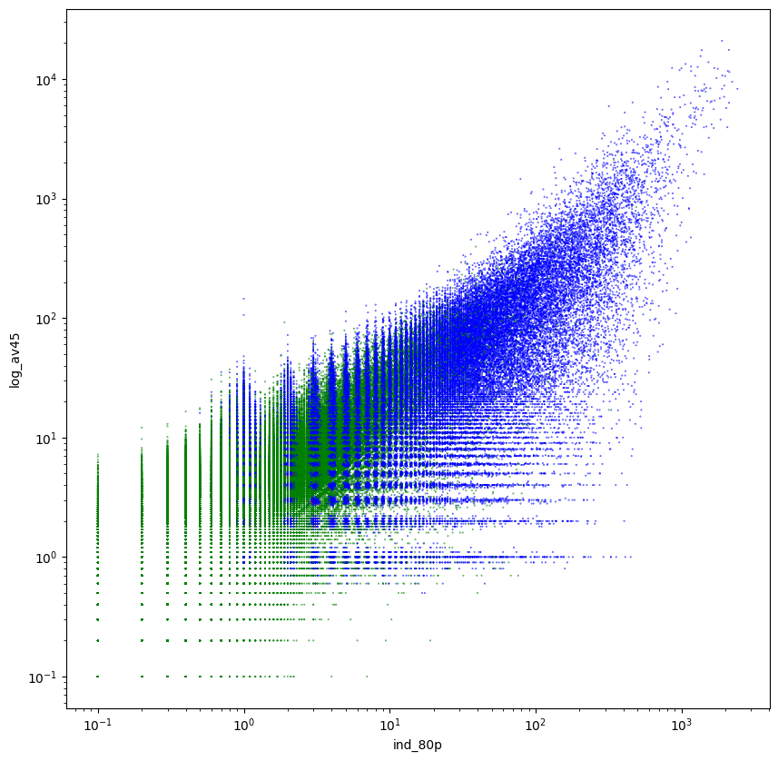

```python
ax = filosofi.plot(figsize=(10,10), kind="scatter", x=var_1, y=var_2, c=np.array(["blue", "green", "red"])[filosofi["i_est_1km"]], s=0.1)
ax.set_xscale("log")
ax.set_yscale("log")
```

### 1.2) Corrélation

Un lien statistique semble bien exister entre les deux variables. On va donc calculer la corrélation entre les deux :

```python
from scipy.stats import spearmanr, pearsonr

print("Corrélation de Pearson : ", pearsonr(filosofi[var_1], filosofi[var_2]))
print("Corrélation de Spearman : ", spearmanr(filosofi[var_1], filosofi[var_2]))
```

```
Corrélation de Pearson :  PearsonRResult(statistic=np.float64(0.7322642873072113), pvalue=np.float64(0.0))
Corrélation de Spearman :  SignificanceResult(statistic=np.float64(0.7405625506170361), pvalue=np.float64(0.0))
```

La corrélation est **assez forte** (R et $\rho$ >0.7), **positive** et **significative** (p-value très faible).

Cependant, ces deux variables sont en fait liées toutes les deux au nombre total d'habitants! On va donc diviser chacune par `ind`.

```python
print("Corrélation de Pearson entre var_1 et ind : ", pearsonr(filosofi[var_1], filosofi["ind"]))
print("Corrélation de Pearson entre var_2 et ind : ", pearsonr(filosofi[var_2], filosofi["ind"]))
```

```
Corrélation de Pearson entre var_1 et ind :  PearsonRResult(statistic=np.float64(0.9127798594694922), pvalue=np.float64(0.0))
Corrélation de Pearson entre var_2 et ind :  PearsonRResult(statistic=np.float64(0.774901356046622), pvalue=np.float64(0.0))
```

```python
filosofi["proportion_habitant_sup_80"] = filosofi["ind_80p"] / filosofi["ind"]
filosofi["proportion_habitant_dans_avant_1945"] = filosofi["log_av45"] / filosofi["ind"]
```

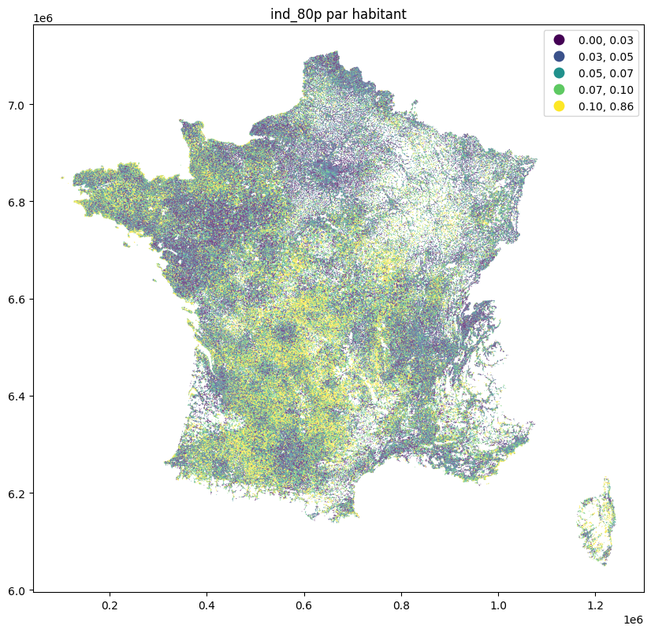

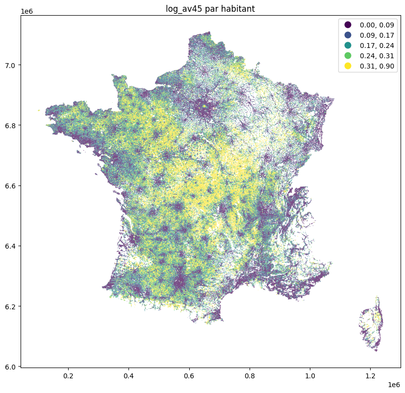

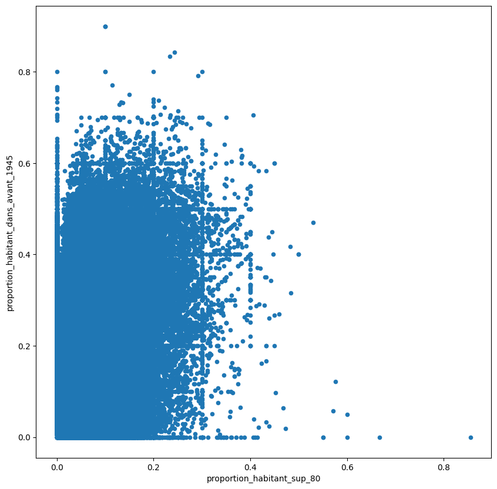

```python
filosofi.plot(figsize=(10,10), column="proportion_habitant_sup_80", legend=True, scheme="quantiles", k=5).set_title(var_1+" par habitant")
filosofi.plot(figsize=(10,10), column="proportion_habitant_dans_avant_1945", legend=True, scheme="quantiles", k=5).set_title(var_2+" par habitant")
filosofi.plot(figsize=(10,10), kind="scatter", x="proportion_habitant_sup_80", y="proportion_habitant_dans_avant_1945")
```

Les données sont écrasées vers les faibles valeurs. On va afficher le scatter plot avec une échelle logarithmique pour mieux étaler les valeurs.

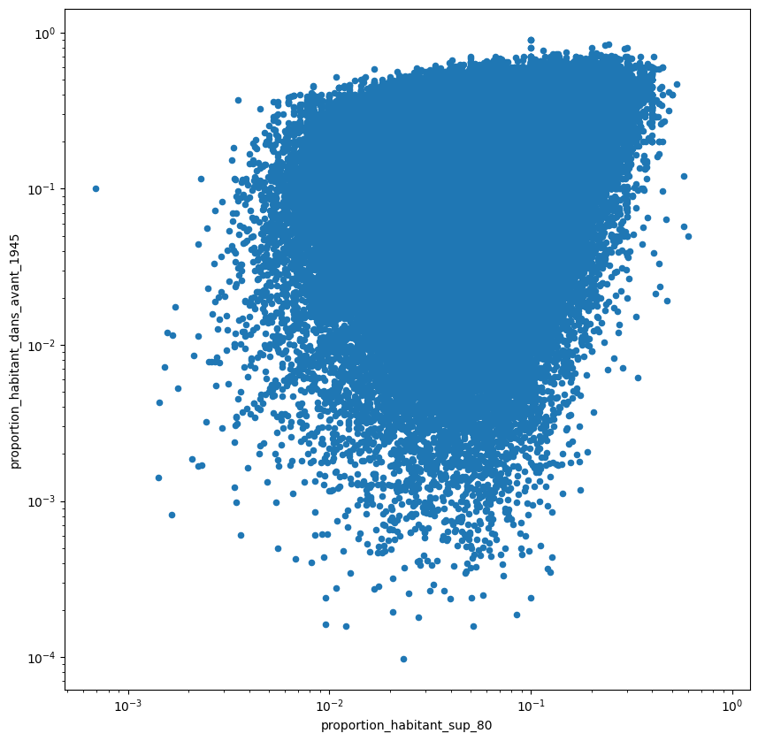

```python
ax = filosofi.plot(figsize=(10,10), kind="scatter", x="proportion_habitant_sup_80", y="proportion_habitant_dans_avant_1945")
ax.set_xscale("log")
ax.set_yscale("log")
```

```python
print("Corrélation de Pearson : ", pearsonr(filosofi["proportion_habitant_sup_80"], filosofi["proportion_habitant_dans_avant_1945"]))
print("Corrélation de Spearman : ", spearmanr(filosofi["proportion_habitant_sup_80"], filosofi["proportion_habitant_dans_avant_1945"]))
```

```
Corrélation de Pearson :  PearsonRResult(statistic=np.float64(0.30676528673616194), pvalue=np.float64(0.0))
Corrélation de Spearman :  SignificanceResult(statistic=np.float64(0.2875337925247301), pvalue=np.float64(0.0))
```

On constate que la corrélation est bien moins forte ! On a encore une corrélation, encore **positive** et **significative**, mais plutôt **faible** (R=0.3)

### 1.3) Régression

On va essayer de prédire le niveau de vie en fonction du nombre de logements construit avant 1945.

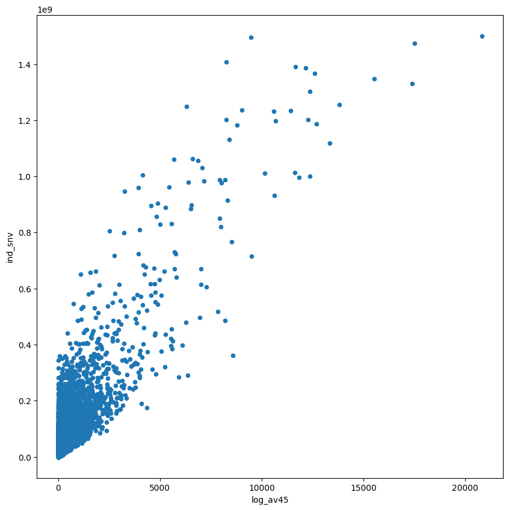

```python
var_3 = "log_av45"
var_4 = "ind_snv"
filosofi.plot(figsize=(10,10), kind="scatter", x=var_3, y=var_4)
```

Il semble exister un lien statistique entre ces deux variables, et il a l'air à peu près linéaire. Faire une regression semble donc pertinent.

```python
from scipy.stats import linregress

reg = linregress(filosofi[var_3], filosofi[var_4])
print("R²:", (reg.rvalue)**2, "p-value:", reg.pvalue)
```

```
R²: 0.7085580778444482 p-value: 0.0
```

Le R² est assez élevé : le modèle linéaire prédit bien le niveau de vie. La p-value est très faible : on peut rejetter l'indépendance des variables avec une grande certitude.

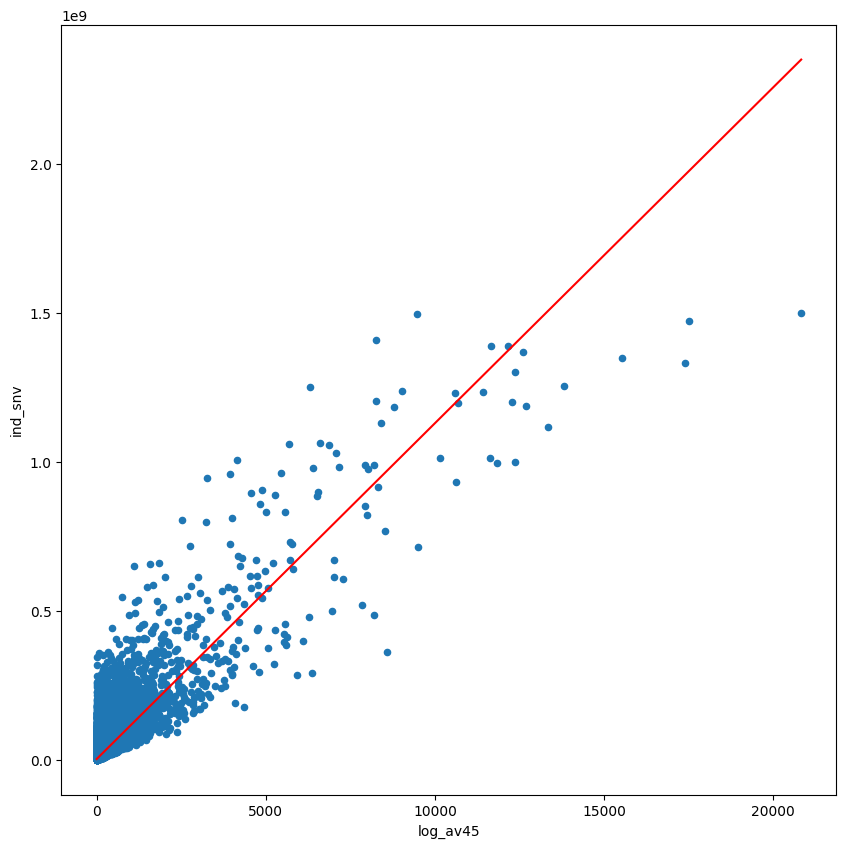

```python
var_3 = "log_av45"
var_4 = "ind_snv"
ax = filosofi.plot(figsize=(10,10), kind="scatter", x=var_3, y=var_4)
#Affichage de la droite de régression
plt.plot(
    [filosofi[var_3].min(), filosofi[var_3].max()],
    [reg.intercept + reg.slope * filosofi[var_3].min(), reg.intercept + reg.slope * filosofi[var_3].max()],
    color="red"
    )
```

## 2) Analyse bivariée entre deux variables qualitatives

Les distributions de CODE_CS et CODE_US sont-elles indépendantes ?

```python
ocs_ge = gpd.read_file("OCCUPATION_SOL.shp")
```

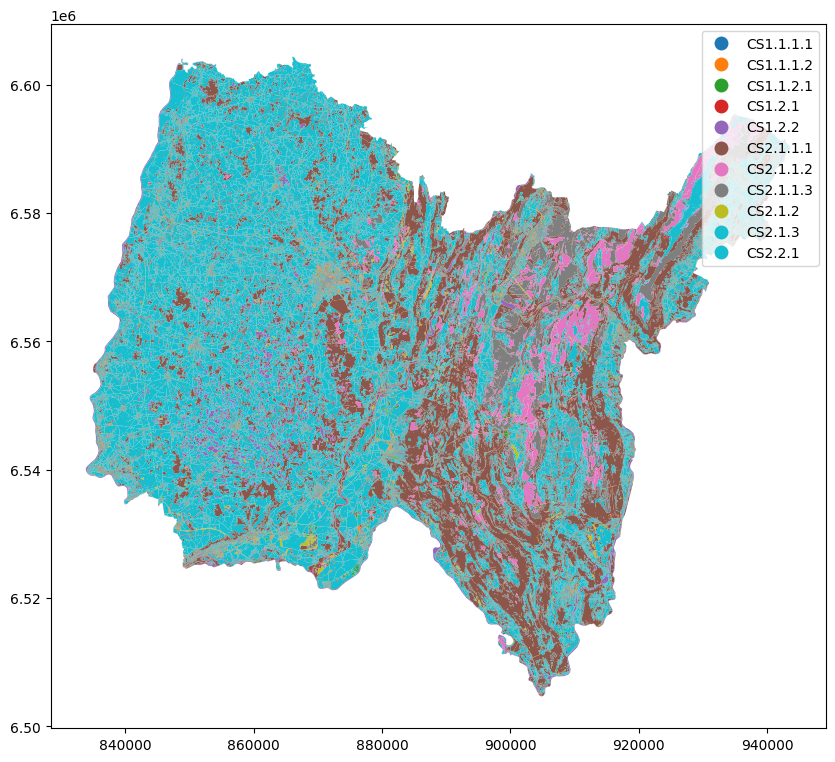

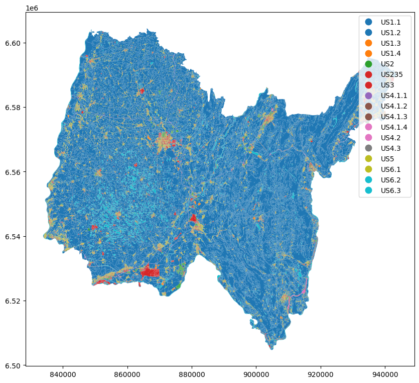

```python
ocs_ge.plot(figsize=(10,10), column="CODE_CS", legend=True)
ocs_ge.plot(figsize=(10,10), column="CODE_US", legend=True)
```

On affiche la table de contingence entre couverture et usage du sol :

```python
effectifs_observes = pd.crosstab(ocs_ge["CODE_CS"], ocs_ge["CODE_US"])
effectifs_observes
```

| CODE_US CODE_CS | US1.1 | US1.2 | US1.3 | US1.4 | US2 | US235 | US3 | US4.1.1 | US4.1.2 | US4.1.3 | US4.1.4 | US4.2 | US4.3 | US5 | US6.1 | US6.2 | US6.3 |
| --- | --- | --- | --- | --- | --- | --- | --- | --- | --- | --- | --- | --- | --- | --- | --- | --- | --- |
| CS1.1.1.1 | 13113 | 0 | 82 | 8 | 4024 | 48 | 10954 | 49 | 133 | 0 | 1 | 19 | 361 | 114534 | 346 | 89 | 0 |
| CS1.1.1.2 | 597 | 0 | 8 | 4 | 1672 | 6 | 5555 | 33942 | 145 | 5 | 1 | 13 | 181 | 12490 | 6 | 0 | 0 |
| CS1.1.2.1 | 4329 | 0 | 98 | 9 | 1051 | 32 | 2549 | 84 | 1956 | 0 | 0 | 4 | 98 | 2687 | 483 | 2 | 0 |
| CS1.2.1 | 0 | 0 | 0 | 0 | 0 | 0 | 0 | 0 | 0 | 0 | 0 | 0 | 0 | 0 | 0 | 0 | 362 |
| CS1.2.2 | 12 | 0 | 38 | 11 | 26 | 0 | 157 | 5 | 0 | 0 | 11 | 0 | 73 | 157 | 0 | 0 | 2696 |
| CS2.1.1.1 | 259 | 10879 | 40 | 0 | 483 | 3 | 2237 | 332 | 0 | 0 | 0 | 0 | 0 | 13739 | 0 | 0 | 13656 |
| CS2.1.1.2 | 0 | 1701 | 1 | 0 | 3 | 1 | 41 | 1 | 0 | 0 | 0 | 0 | 0 | 104 | 0 | 0 | 141 |
| CS2.1.1.3 | 0 | 2101 | 1 | 0 | 16 | 0 | 143 | 9 | 0 | 0 | 0 | 0 | 0 | 733 | 0 | 0 | 351 |
| CS2.1.2 | 178 | 4 | 26 | 0 | 18 | 0 | 69 | 54 | 80 | 0 | 0 | 0 | 339 | 93 | 2 | 0 | 2917 |
| CS2.1.3 | 571 | 0 | 0 | 0 | 0 | 0 | 0 | 0 | 0 | 0 | 0 | 0 | 0 | 5 | 0 | 0 | 0 |
| CS2.2.1 | 19263 | 0 | 95 | 7 | 2111 | 8 | 6640 | 1035 | 221 | 10 | 0 | 21 | 598 | 43590 | 113 | 0 | 4700 |

On peut directement réaliser le test avec la fonction `chi2_contingency` de scipy.

```python
from scipy.stats import chi2_contingency
chi2, p, ddl, expected = chi2_contingency(effectifs_observes)
print("\n--- Résultats du Test du Chi2 ---")
print(f"Statistique du Chi2 (χ²): {chi2:.4f}")
print(f"p-valeur (p): {p:.4f}")
print(f"Degrés de liberté (ddl): {ddl}")
```

```
--- Résultats du Test du Chi2 ---
Statistique du Chi2 (χ²): 525035.8906
p-valeur (p): 0.0000
Degrés de liberté (ddl): 160
```

La p-valeur est très faible (inférieure à $10^{-5}$). On peut donc rejetter l'hypothèse d'indépendance avec une certitude importante.

On peut aussi faire toutes les étapes du Chi2 :

```python
frequences_observes = effectifs_observes/ocs_ge.shape[0]
frequences_observes
```

| CODE_US CODE_CS | US1.1 | US1.2 | US1.3 | US1.4 | US2 | US235 | US3 | US4.1.1 | US4.1.2 | US4.1.3 | US4.1.4 | US4.2 | US4.3 | US5 | US6.1 | US6.2 | US6.3 |
| --- | --- | --- | --- | --- | --- | --- | --- | --- | --- | --- | --- | --- | --- | --- | --- | --- | --- |
| CS1.1.1.1 | 0.038002 | 0.000000 | 0.000238 | 0.000023 | 0.011662 | 0.000139 | 0.031745 | 0.000142 | 0.000385 | 0.000000 | 0.000003 | 0.000055 | 0.001046 | 0.331926 | 0.001003 | 0.000258 | 0.000000 |
| CS1.1.1.2 | 0.001730 | 0.000000 | 0.000023 | 0.000012 | 0.004846 | 0.000017 | 0.016099 | 0.098366 | 0.000420 | 0.000014 | 0.000003 | 0.000038 | 0.000525 | 0.036197 | 0.000017 | 0.000000 | 0.000000 |
| CS1.1.2.1 | 0.012546 | 0.000000 | 0.000284 | 0.000026 | 0.003046 | 0.000093 | 0.007387 | 0.000243 | 0.005669 | 0.000000 | 0.000000 | 0.000012 | 0.000284 | 0.007787 | 0.001400 | 0.000006 | 0.000000 |
| CS1.2.1 | 0.000000 | 0.000000 | 0.000000 | 0.000000 | 0.000000 | 0.000000 | 0.000000 | 0.000000 | 0.000000 | 0.000000 | 0.000000 | 0.000000 | 0.000000 | 0.000000 | 0.000000 | 0.000000 | 0.001049 |
| CS1.2.2 | 0.000035 | 0.000000 | 0.000110 | 0.000032 | 0.000075 | 0.000000 | 0.000455 | 0.000014 | 0.000000 | 0.000000 | 0.000032 | 0.000000 | 0.000212 | 0.000455 | 0.000000 | 0.000000 | 0.007813 |
| CS2.1.1.1 | 0.000751 | 0.031528 | 0.000116 | 0.000000 | 0.001400 | 0.000009 | 0.006483 | 0.000962 | 0.000000 | 0.000000 | 0.000000 | 0.000000 | 0.000000 | 0.039816 | 0.000000 | 0.000000 | 0.039576 |
| CS2.1.1.2 | 0.000000 | 0.004930 | 0.000003 | 0.000000 | 0.000009 | 0.000003 | 0.000119 | 0.000003 | 0.000000 | 0.000000 | 0.000000 | 0.000000 | 0.000000 | 0.000301 | 0.000000 | 0.000000 | 0.000409 |
| CS2.1.1.3 | 0.000000 | 0.006089 | 0.000003 | 0.000000 | 0.000046 | 0.000000 | 0.000414 | 0.000026 | 0.000000 | 0.000000 | 0.000000 | 0.000000 | 0.000000 | 0.002124 | 0.000000 | 0.000000 | 0.001017 |
| CS2.1.2 | 0.000516 | 0.000012 | 0.000075 | 0.000000 | 0.000052 | 0.000000 | 0.000200 | 0.000156 | 0.000232 | 0.000000 | 0.000000 | 0.000000 | 0.000982 | 0.000270 | 0.000006 | 0.000000 | 0.008454 |
| CS2.1.3 | 0.001655 | 0.000000 | 0.000000 | 0.000000 | 0.000000 | 0.000000 | 0.000000 | 0.000000 | 0.000000 | 0.000000 | 0.000000 | 0.000000 | 0.000000 | 0.000014 | 0.000000 | 0.000000 | 0.000000 |
| CS2.2.1 | 0.055825 | 0.000000 | 0.000275 | 0.000020 | 0.006118 | 0.000023 | 0.019243 | 0.002999 | 0.000640 | 0.000029 | 0.000000 | 0.000061 | 0.001733 | 0.126326 | 0.000327 | 0.000000 | 0.013621 |

```python
frequences_usages = frequences_observes.sum(axis=0)
display(frequences_usages)

frequences_couvertures = frequences_observes.sum(axis=1)
display(frequences_couvertures)
```

| CODE_US | 0 |
| --- | --- |
| US1.1 | 0.111059 |
| US1.2 | 0.042558 |
| US1.3 | 0.001127 |
| US1.4 | 0.000113 |
| US2 | 0.027253 |
| US235 | 0.000284 |
| US3 | 0.082145 |
| US4.1.1 | 0.102913 |
| US4.1.2 | 0.007347 |
| US4.1.3 | 0.000043 |
| US4.1.4 | 0.000038 |
| US4.2 | 0.000165 |
| US4.3 | 0.004782 |
| US5 | 0.545217 |
| US6.1 | 0.002753 |
| US6.2 | 0.000264 |
| US6.3 | 0.071938 |

**dtype:** float64

| CODE_CS | 0 |
| --- | --- |
| CS1.1.1.1 | 0.416627 |
| CS1.1.1.2 | 0.158306 |
| CS1.1.2.1 | 0.038782 |
| CS1.2.1 | 0.001049 |
| CS1.2.2 | 0.009233 |
| CS2.1.1.1 | 0.120640 |
| CS2.1.1.2 | 0.005776 |
| CS2.1.1.3 | 0.009720 |
| CS2.1.2 | 0.010955 |
| CS2.1.3 | 0.001669 |
| CS2.2.1 | 0.227242 |

**dtype:** float64

```python
frequences_theoriques = pd.DataFrame(
    frequences_couvertures.to_numpy().reshape(-1,1).dot(frequences_usages.to_numpy().reshape(1,-1)),
    index = frequences_couvertures.index,
    columns = frequences_usages.index
)
frequences_theoriques
```

| CODE_US CODE_CS | US1.1 | US1.2 | US1.3 | US1.4 | US2 | US235 | US3 | US4.1.1 | US4.1.2 | US4.1.3 | US4.1.4 | US4.2 | US4.3 | US5 | US6.1 | US6.2 | US6.3 |
| --- | --- | --- | --- | --- | --- | --- | --- | --- | --- | --- | --- | --- | --- | --- | --- | --- | --- |
| CS1.1.1.1 | 0.046270 | 0.017731 | 0.000470 | 4.708895e-05 | 0.011354 | 1.183261e-04 | 0.034224 | 0.042876 | 0.003061 | 1.811113e-05 | 1.569632e-05 | 6.882231e-05 | 0.001992 | 0.227152 | 0.001147 | 1.098742e-04 | 0.029972 |
| CS1.1.1.2 | 0.017581 | 0.006737 | 0.000178 | 1.789243e-05 | 0.004314 | 4.496047e-05 | 0.013004 | 0.016292 | 0.001163 | 6.881704e-06 | 5.964143e-06 | 2.615048e-05 | 0.000757 | 0.086311 | 0.000436 | 4.174900e-05 | 0.011388 |
| CS1.1.2.1 | 0.004307 | 0.001650 | 0.000044 | 4.383277e-06 | 0.001057 | 1.101439e-05 | 0.003186 | 0.003991 | 0.000285 | 1.685876e-06 | 1.461092e-06 | 6.406328e-06 | 0.000185 | 0.021144 | 0.000107 | 1.022765e-05 | 0.002790 |
| CS1.2.1 | 0.000117 | 0.000045 | 0.000001 | 1.185732e-07 | 0.000029 | 2.979531e-07 | 0.000086 | 0.000108 | 0.000008 | 4.560507e-08 | 3.952439e-08 | 1.732993e-07 | 0.000005 | 0.000572 | 0.000003 | 2.766707e-07 | 0.000075 |
| CS1.2.2 | 0.001025 | 0.000393 | 0.000010 | 1.043575e-06 | 0.000252 | 2.622317e-06 | 0.000758 | 0.000950 | 0.000068 | 4.013750e-07 | 3.478583e-07 | 1.525225e-06 | 0.000044 | 0.005034 | 0.000025 | 2.435008e-06 | 0.000664 |
| CS2.1.1.1 | 0.013398 | 0.005134 | 0.000136 | 1.363526e-05 | 0.003288 | 3.426296e-05 | 0.009910 | 0.012415 | 0.000886 | 5.244331e-06 | 4.545087e-06 | 1.992846e-05 | 0.000577 | 0.065775 | 0.000332 | 3.181561e-05 | 0.008679 |
| CS2.1.1.2 | 0.000641 | 0.000246 | 0.000007 | 6.528076e-07 | 0.000157 | 1.640388e-06 | 0.000474 | 0.000594 | 0.000042 | 2.510798e-07 | 2.176025e-07 | 9.541034e-07 | 0.000028 | 0.003149 | 0.000016 | 1.523218e-06 | 0.000416 |
| CS2.1.1.3 | 0.001080 | 0.000414 | 0.000011 | 1.098603e-06 | 0.000265 | 2.760593e-06 | 0.000798 | 0.001000 | 0.000071 | 4.225398e-07 | 3.662011e-07 | 1.605651e-06 | 0.000046 | 0.005300 | 0.000027 | 2.563408e-06 | 0.000699 |
| CS2.1.2 | 0.001217 | 0.000466 | 0.000012 | 1.238140e-06 | 0.000299 | 3.111223e-06 | 0.000900 | 0.001127 | 0.000080 | 4.762076e-07 | 4.127133e-07 | 1.809589e-06 | 0.000052 | 0.005973 | 0.000030 | 2.888993e-06 | 0.000788 |
| CS2.1.3 | 0.000185 | 0.000071 | 0.000002 | 1.886689e-07 | 0.000045 | 4.740911e-07 | 0.000137 | 0.000172 | 0.000012 | 7.256497e-08 | 6.288964e-08 | 2.757469e-07 | 0.000008 | 0.000910 | 0.000005 | 4.402275e-07 | 0.000120 |
| CS2.2.1 | 0.025237 | 0.009671 | 0.000256 | 2.568387e-05 | 0.006193 | 6.453895e-05 | 0.018667 | 0.023386 | 0.001669 | 9.878411e-06 | 8.561289e-06 | 3.753796e-05 | 0.001087 | 0.123896 | 0.000626 | 5.992902e-05 | 0.016347 |

```python
effectifs_theoriques = frequences_theoriques * ocs_ge.shape[0]
effectifs_theoriques
```

| CODE_US CODE_CS | US1.1 | US1.2 | US1.3 | US1.4 | US2 | US235 | US3 | US4.1.1 | US4.1.2 | US4.1.3 | US4.1.4 | US4.2 | US4.3 | US5 | US6.1 | US6.2 | US6.3 |
| --- | --- | --- | --- | --- | --- | --- | --- | --- | --- | --- | --- | --- | --- | --- | --- | --- | --- |
| CS1.1.1.1 | 15965.991445 | 6118.171921 | 162.068020 | 16.248465 | 3917.963143 | 40.829476 | 11809.300859 | 14794.852101 | 1056.150209 | 6.249410 | 5.416155 | 23.747756 | 687.435047 | 78380.927470 | 395.795936 | 37.913084 | 10341.939503 |
| CS1.1.1.2 | 6066.612521 | 2324.727438 | 61.581135 | 6.173944 | 1488.712075 | 15.514014 | 4487.190959 | 5621.613623 | 401.306371 | 2.374594 | 2.057981 | 9.023457 | 261.205330 | 29782.473432 | 150.390948 | 14.405870 | 3929.636309 |
| CS1.1.2.1 | 1486.195126 | 569.510345 | 15.086110 | 1.512489 | 364.703798 | 3.800614 | 1099.269371 | 1377.179561 | 98.311796 | 0.581727 | 0.504163 | 2.210561 | 63.989926 | 7296.092622 | 36.842685 | 3.529141 | 962.679965 |
| CS1.2.1 | 40.203455 | 15.405974 | 0.408098 | 0.040915 | 9.865698 | 0.102811 | 29.736625 | 37.254446 | 2.659458 | 0.015736 | 0.013638 | 0.059798 | 1.731008 | 197.368520 | 0.996641 | 0.095468 | 26.041709 |
| CS1.2.2 | 353.834828 | 135.589595 | 3.591716 | 0.360095 | 86.829047 | 0.904854 | 261.715156 | 327.880293 | 23.406171 | 0.138498 | 0.120032 | 0.526293 | 15.234786 | 1737.061059 | 8.771543 | 0.840222 | 229.195813 |
| CS2.1.1.1 | 4623.175214 | 1771.601900 | 46.929053 | 4.704969 | 1134.500801 | 11.822743 | 3419.547556 | 4284.055504 | 305.823004 | 1.809604 | 1.568323 | 6.876494 | 199.056393 | 22696.289319 | 114.608226 | 10.978262 | 2994.652636 |
| CS2.1.1.2 | 221.341121 | 84.817973 | 2.246795 | 0.225257 | 54.315847 | 0.566031 | 163.715727 | 205.105281 | 14.641713 | 0.086637 | 0.075086 | 0.329222 | 9.530109 | 1086.617292 | 5.487033 | 0.525600 | 143.373275 |
| CS2.1.1.3 | 372.492785 | 142.739329 | 3.781110 | 0.379083 | 91.407603 | 0.952568 | 275.515578 | 345.169649 | 24.640395 | 0.145801 | 0.126361 | 0.554044 | 16.038127 | 1828.657499 | 9.234073 | 0.884527 | 241.281468 |
| CS2.1.2 | 419.804034 | 160.869011 | 4.261358 | 0.427231 | 103.017513 | 1.073556 | 310.509507 | 389.010517 | 27.770034 | 0.164320 | 0.142410 | 0.624415 | 18.075170 | 2060.919901 | 10.406916 | 0.996873 | 271.927236 |
| CS2.1.3 | 63.970138 | 24.513373 | 0.649350 | 0.065102 | 15.697907 | 0.163589 | 47.315734 | 59.277793 | 4.231624 | 0.025039 | 0.021701 | 0.095149 | 2.754312 | 314.044937 | 1.585816 | 0.151904 | 41.436531 |
| CS2.2.1 | 8708.379332 | 3337.053142 | 88.397254 | 8.862450 | 2136.986568 | 22.269745 | 6441.182928 | 8069.601233 | 576.059225 | 3.408634 | 2.954150 | 12.952811 | 374.949791 | 42751.547950 | 215.880183 | 20.679049 | 5640.835556 |

```python
test_chi2 = ((effectifs_observes - effectifs_theoriques)**2/effectifs_theoriques).sum().sum()
test_chi2
```

```
np.float64(525035.8906068673)
```

```python
from scipy.stats import chi2

degre_de_liberte = (len(frequences_usages)-1) * (len(frequences_couvertures)-1)
p_value = 0.01

valeur_critique = chi2.ppf(1 - p_value, degre_de_liberte)

print(f"La valeur critique du chi2 pour un degré de liberté={degre_de_liberte} et une p-value={p_value} est : {valeur_critique}")
```

```
La valeur critique du chi2 pour un degré de liberté=160 et une p-value=0.01 est : 204.5300945903855
```

La valeur obtenue par le test du Chi² est bien supérieure à la valeur critique. On peut donc rejetter l'indépendance des deux variables, avec moins d'1% de chance de se tromper.

## Analyse bivariée entre une variable qualitative et une variable quantitative

On va d'abord restreindre le fichier filosofi au département de l'Ain. On va utiliser le code des communes pour faire cette selection facilement

```python
filosofi_ain = filosofi[filosofi["lcog_geo"].str.startswith("01")]
#Ce qu'il y a entre les crochets est une pd.Series de Booleen "True" quand le carreaux est dans l'Ain et False sinon.
#La syntaxe df[booleen_serie] permet de renvoyer le sous ensemble du dataframe initial avec tous les indices pour lesquels booleen_serie est "True"
```

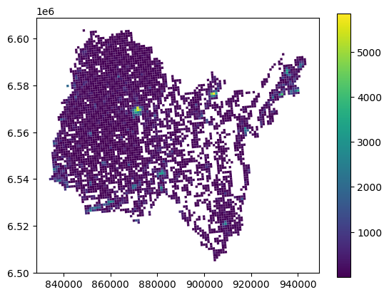

```python
filosofi_ain.plot(column="ind", legend=True)
```

On va réaliser l'intersection entre les deux couches

```python
intersection = ocs_ge.overlay(filosofi_ain,
                              how="intersection",
                              keep_geom_type=True
                              )
```

Chaque polygone de cette intersection a un usage bien défini. On va désagréger la population à l'échelle de ces unités cartographiques en faisant l'hypothèse que la population est répartie de manière homogène dans les carreaux de 1 km.

```python
intersection["ind_estimee"] = intersection["ind"] * (intersection.area/1000000)
```

```python
intersection.head()
```

|  | ID | CODE_CS | CODE_US | MILLESIME | SOURCE | OSSATURE | ID_ORIGINE | CODE_OR | idcar_1km | i_est_1km | ... | ind_25_39 | ind_40_54 | ind_55_64 | ind_65_79 | ind_80p | ind_inc | proportion_habitant_sup_80 | proportion_habitant_dans_avant_1945 | geometry | ind_estimee |
| --- | --- | --- | --- | --- | --- | --- | --- | --- | --- | --- | --- | --- | --- | --- | --- | --- | --- | --- | --- | --- | --- |
| 0 | OCSGE0000000010019471939 | CS1.1.1.1 | US5 | 2021 | calcul | 0 | NC | NC | CRS3035RES1000mN2580000E4012000 | 0 | ... | 6.0 | 31.0 | 7.0 | 11.0 | 2.1 | 0.0 | 0.023204 | 0.000000 | POLYGON ((930611.6 6577732.26, 930609.6 657773... | 0.029604 |
| 1 | OCSGE0000000010019471929 | CS1.1.1.1 | US5 | 2021 | calcul | 0 | NC | NC | CRS3035RES1000mN2580000E4011000 | 1 | ... | 41.8 | 66.0 | 34.5 | 47.7 | 13.9 | 0.0 | 0.047039 | 0.019966 | POLYGON ((930397.1 6577673.9, 930388.11 657768... | 0.128211 |
| 2 | OCSGE0000000010019471930 | CS1.1.1.1 | US5 | 2021 | calcul | 0 | NC | NC | CRS3035RES1000mN2580000E4011000 | 1 | ... | 41.8 | 66.0 | 34.5 | 47.7 | 13.9 | 0.0 | 0.047039 | 0.019966 | POLYGON ((929937.96 6577691.9, 929926.31 65777... | 0.059096 |
| 3 | OCSGE0000000010019471931 | CS1.1.1.1 | US5 | 2021 | calcul | 0 | NC | NC | CRS3035RES1000mN2580000E4012000 | 0 | ... | 6.0 | 31.0 | 7.0 | 11.0 | 2.1 | 0.0 | 0.023204 | 0.000000 | POLYGON ((930752.74 6577721, 930766.5 6577715.... | 0.021780 |
| 4 | OCSGE0000000010019471932 | CS1.1.1.1 | US5 | 2021 | calcul | 0 | NC | NC | CRS3035RES1000mN2580000E4011000 | 1 | ... | 41.8 | 66.0 | 34.5 | 47.7 | 13.9 | 0.0 | 0.047039 | 0.019966 | POLYGON ((930382.8 6577714.3, 930394.16 657772... | 0.062773 |

5 rows × 43 columns

```python
intersection["ind_estimee"].head()
```

|  | ind_estimee |
| --- | --- |
| 0 | 0.029604 |
| 1 | 0.128211 |
| 2 | 0.059096 |
| 3 | 0.021780 |
| 4 | 0.062773 |

**dtype:** float64

Certains morceaux n'ont pas été intersectés. Ils ont pour l'instant une valeur "ind_estimee": NaN. Pour notre analyse, on va considérer qu'ils ont une population nulle.

```python
intersection["ind_estimee"] = intersection["ind_estimee"].fillna(0)
```

On va regrouper au niveau des unités cartographiques initiales de l'OCS GE. Pour cela, on va faire la somme des populations estimées par ID de l'OCS GE.

```python
pop_par_ocsge = intersection.groupby("ID")["ind_estimee"].sum()
```

```python
ocs_ge = ocs_ge.set_index("ID")
ocs_ge["ind_estimee"] = pop_par_ocsge
```

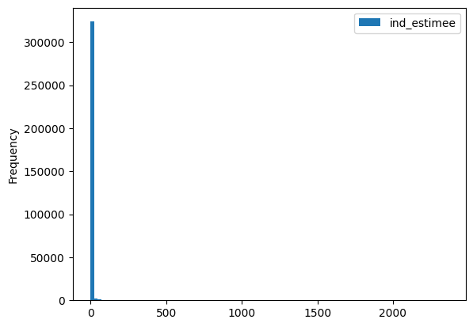

```python
ocs_ge.plot(kind="hist", column="ind_estimee", bins=100)
```

L'histogramme montre qu'une très grande majorité des polygones a une population très faible, et que la distribution est très asymétrique. On va donc faire une tranformation logarithmique

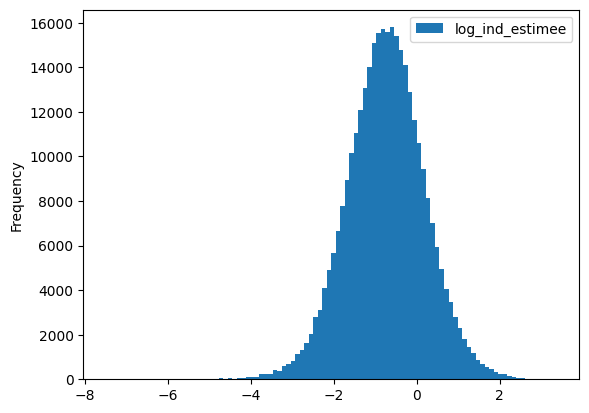

```python
ocs_ge["log_ind_estimee"] = np.log10(ocs_ge["ind_estimee"])
ocs_ge.plot(kind="hist", column="log_ind_estimee", bins=100)
```

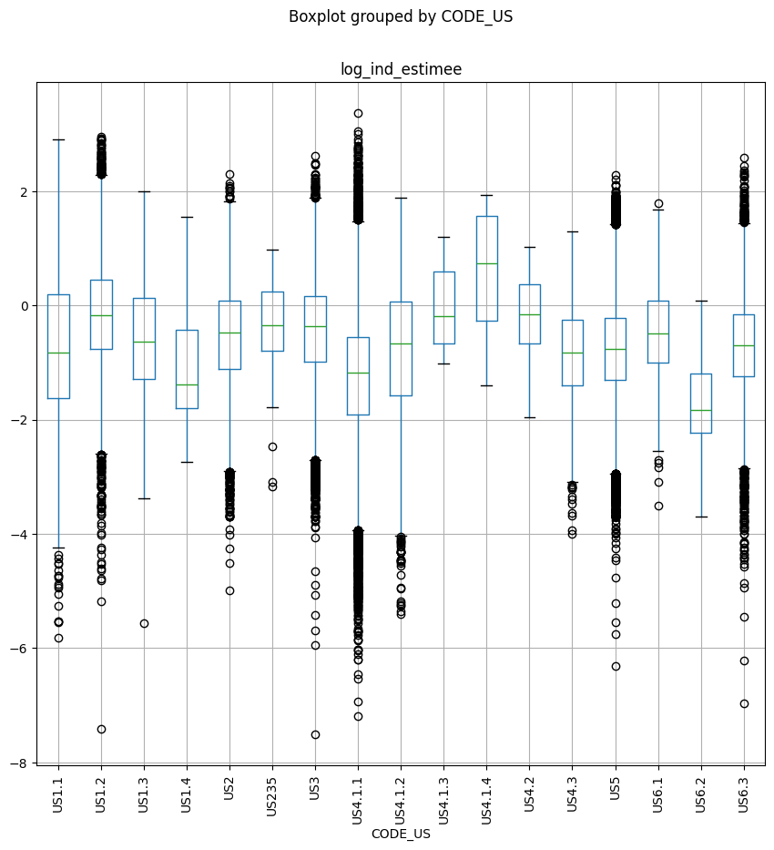

```python
ocs_ge.boxplot(column="log_ind_estimee", by="CODE_US", figsize=(10,10), rot=90)
```

On constate que les distributions des populations sont différentes selon les usages : il semble exister un lien entre les deux. Pour autant, le modèle qu'on a utilisé pour la désagrégation de la population ne semble pas très pertinent : l'usage avec la plus haute population médiane est l'usage "Navigable" ! D'autre part les unités spatiales ont des tailles très variées, et comparer directement leur population n'est pas si pertinent.

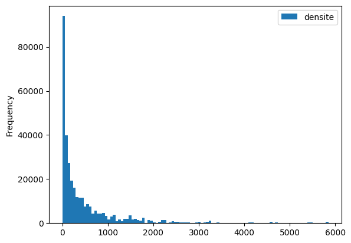

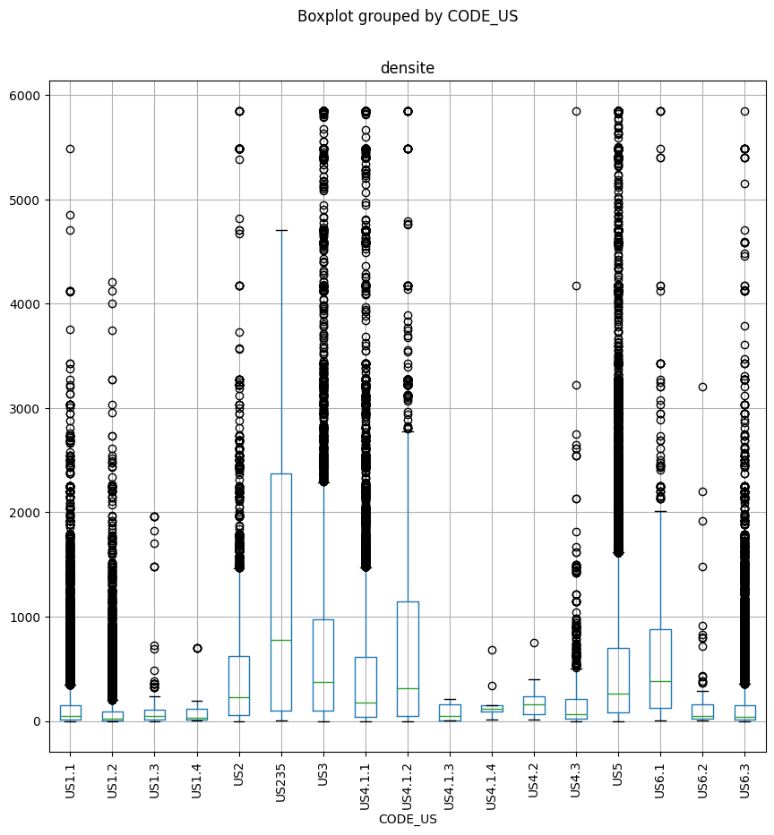

```python
ocs_ge["densite"] = ocs_ge["ind_estimee"]/ocs_ge.area *1000000 #(habitants/km²)
ocs_ge.plot(kind="hist", column="densite", bins=100)
ocs_ge.boxplot(column="densite", by="CODE_US", figsize=(10,10), rot=90)
```

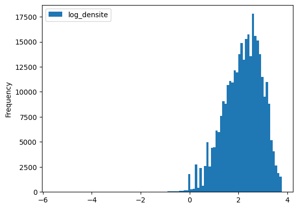

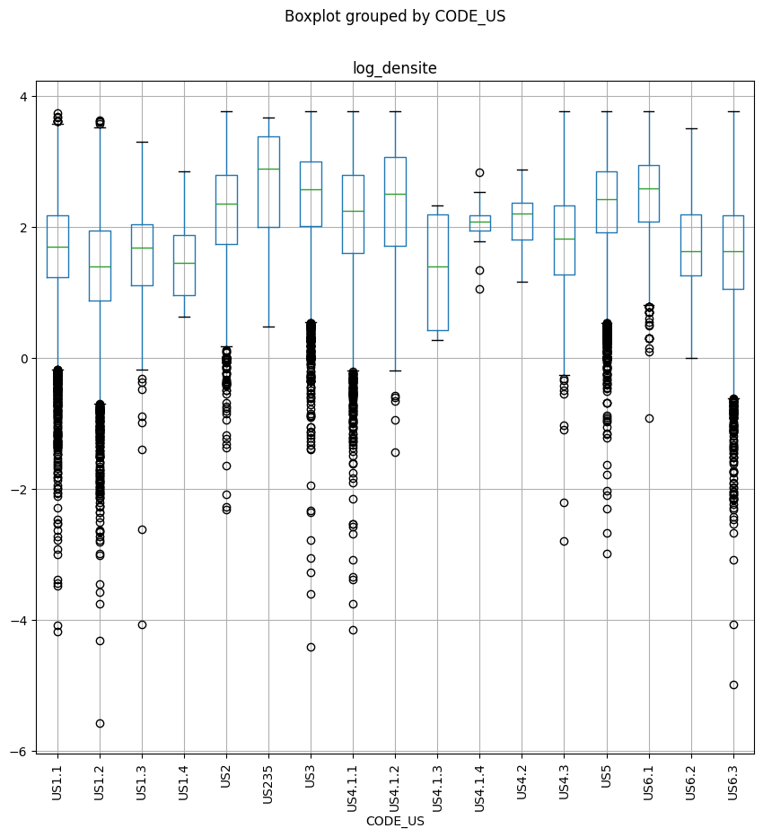

```python
ocs_ge["log_densite"] = np.log10(ocs_ge["densite"])
ocs_ge.plot(kind="hist", column="log_densite", bins=100)
ocs_ge.boxplot(column="log_densite", by="CODE_US", figsize=(10,10), rot=90)
```

On va essayer de faire l'inverse : plutôt que de calculer la population des polygones de l'OCS GE, on va chercher l'usage majoritaire des carreaux.

```python
intersection["intersected_area"] = intersection.area
grouped = intersection.groupby(by=["idcar_1km", "CODE_US"])
```

```python
area_per_US = grouped.aggregate({"intersected_area": "sum"})
```

```python
area_per_US
```

| idcar_1km | CODE_US | intersected_area |
| --- | --- | --- |
| CRS3035RES1000mN2510000E3979000 | US1.1 | 199509.974876 |
|  | US1.2 | 247506.319747 |
|  | US3 | 148022.904047 |
|  | US4.1.1 | 8643.642790 |
|  | US5 | 26332.931045 |
| ... | ... | ... |
| CRS3035RES1000mN2613000E3932000 | US1.2 | 72979.564333 |
|  | US3 | 6874.732000 |
|  | US4.1.1 | 5182.361158 |
|  | US5 | 2594.768041 |
|  | US6.3 | 94273.165015 |

25388 rows × 1 columns

```python
 def main_us(groupe):
    #On définit une fonction d'aggrégation qu'on va appliquer à chaque groupe de carreaux, et qui va retourner l'usage avec la plus grande surface
    return groupe["CODE_US"].iloc[np.argmax(groupe["intersected_area"])]
```

```python
usage_majoritaire = area_per_US.reset_index().groupby("idcar_1km").apply(main_us, include_groups=False)
```

```python
filosofi_ain = filosofi_ain.set_index("idcar_1km")
filosofi_ain["Usage majoritaire"] = usage_majoritaire
```

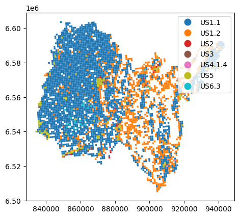

```python
filosofi_ain.plot(column="Usage majoritaire", legend=True)
```

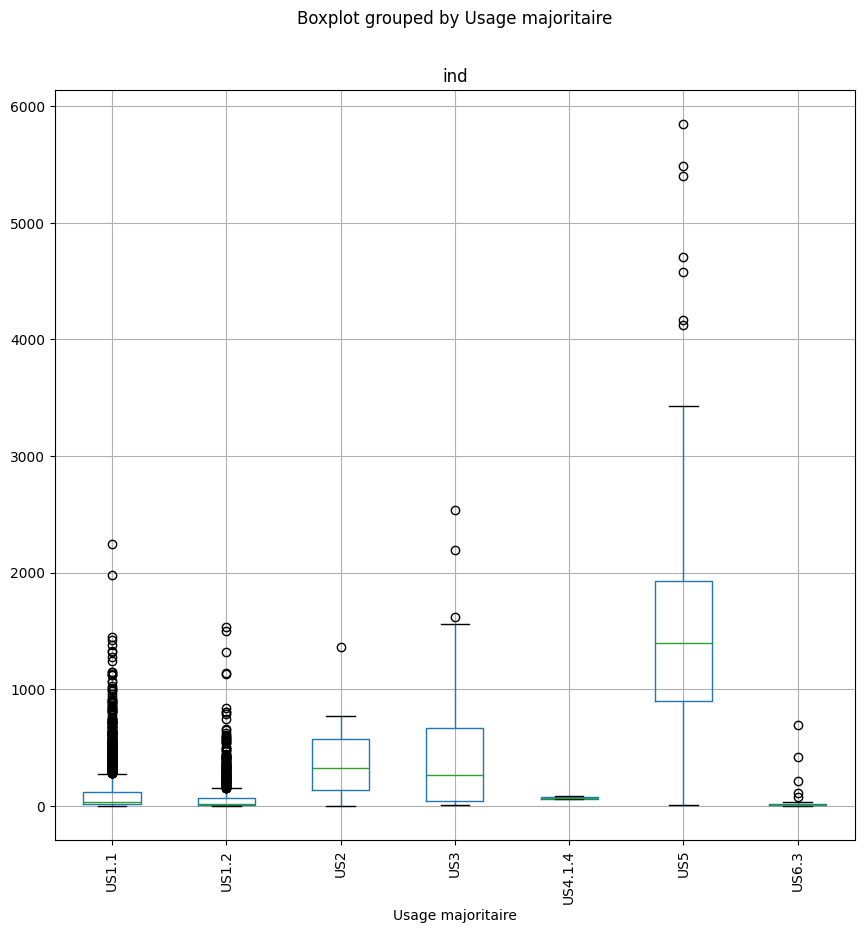

```python
filosofi_ain.boxplot(column="ind", by="Usage majoritaire", figsize=(10,10), rot=90)
```

Ça semble plus crédible

La carte permet de constater une limite à cette approche : les trous correspondent à "des carreaux inhabités", mais qui ont pourtant un usage.